# Lab 10 homework

Stanisław Antonowicz

22/05/2021

# Homework 1

## Analyze data from *Zheng et al., 2017* similarly to the PBMC3k.

I downloaded `fresh_68k_pbmc_donor_a_filtered_gene_bc_matrices.tar.gz` file and uncompressed it.

### Loading libraries, downloading data

```r
library(dplyr)
library(Seurat)
library(patchwork)
library(ggplot2)
```

```r
# Load the PBMC dataset
pbmc.data <- Read10X(data.dir = "/Users/ant/studia/biological-systems-modelling/lab10/filtered_matrices_mex/hg19/")
# Initialize the Seurat object with the raw (non-normalized data).
pbmc <- CreateSeuratObject(counts = pbmc.data, project = "pbmc68k", min.cells = 3, min.features = 200)
pbmc
```

```
An object of class Seurat
17788 features across 68551 samples within 1 assay
Active assay: RNA (17788 features, 0 variable features)
```

### Computing an additional cell-level metric: a percentage of reads that map to the mitochondrial genome

A theoretical justification is that > Low-quality / dying cells often exhibit extensive mitochnodrial contamination.

```r
pbmc[["percent.mt"]] <- PercentageFeatureSet(pbmc, pattern = "^MT-")
```

### Visualizing different metrics, filtering the data

I guess given how many cells are there the plots look worse than in the Seurat tutorial.

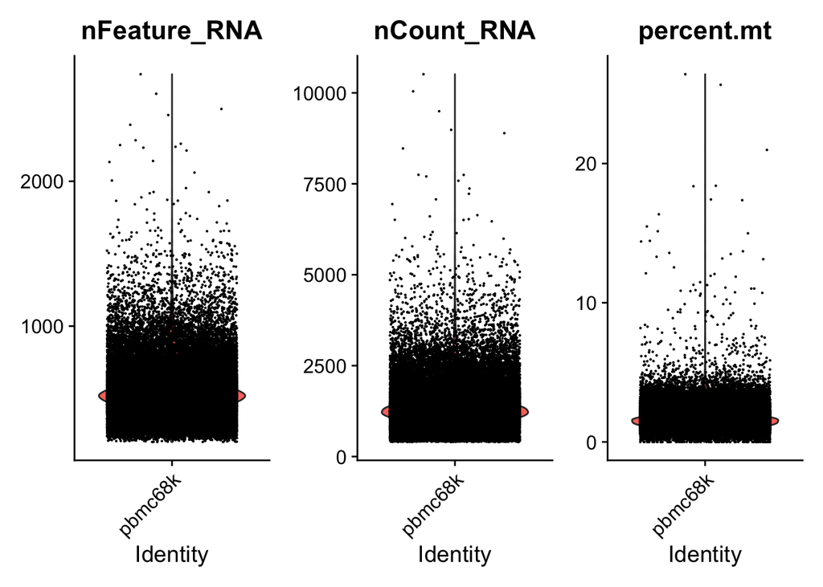

```r
vlnplot <- VlnPlot(pbmc, features = c("nFeature_RNA", "nCount_RNA", "percent.mt"), ncol = 3)
vlnplot
```

Maybe `FeatureScatter` will look better.

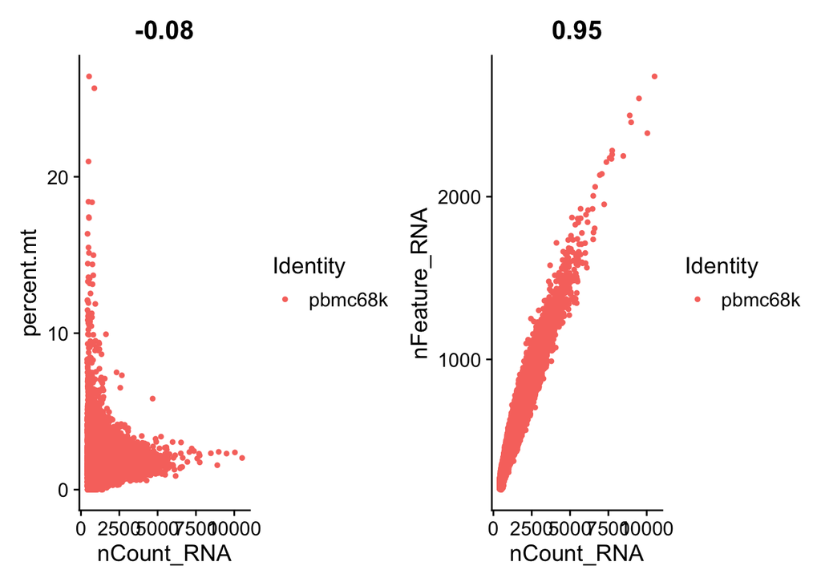

```r
plot1 <- FeatureScatter(pbmc, feature1 = "nCount_RNA", feature2 = "percent.mt")
plot2 <- FeatureScatter(pbmc, feature1 = "nCount_RNA", feature2 = "nFeature_RNA")
plot1 + plot2
```

It looks really similar to the one in Seurat tutorial. I will not change their recommended cutoff values.

```r
pbmc <- subset(pbmc, subset = nFeature_RNA > 200 & nFeature_RNA < 2500 & percent.mt < 5)
```

### Normalizing the data

With the default parameters.

```r
pbmc <- NormalizeData(pbmc)
```

### Selecting highly variable genes

As advised in the Seurat tutorial, the number of most variable genes kept is set to 2000.

```r
pbmc <- FindVariableFeatures(pbmc, selection.method = "vst", nfeatures = 2000)

# Identify the 10 most highly variable genes
top10 <- head(VariableFeatures(pbmc), 10)
print(top10)
```

```
 [1] "PPBP"       "IGJ"        "IGLL5"      "LYZ"        "CST3"
 [6] "PF4"        "HLA-DRA"    "MZB1"       "CD74"       "AL928768.3"
```

```r
# plot variable features with and without labels
plot1 <- VariableFeaturePlot(pbmc)
plot2 <- LabelPoints(plot = plot1, points = top10, repel = TRUE)
```

```
When using repel, set xnudge and ynudge to 0 for optimal results
```

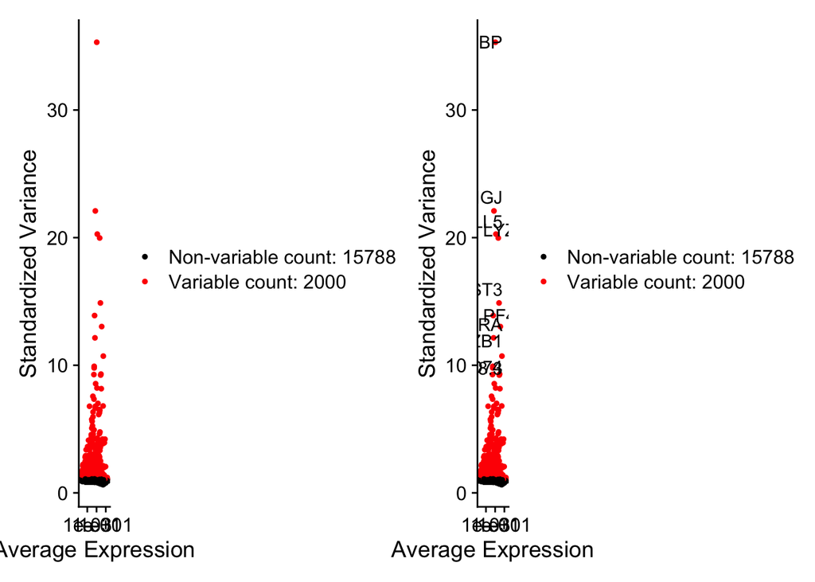

```r
plot1 + plot2
```

Interesting – PPBP is the most highly variable gene in both datasets. Also, PF4, LYZ and IGLL5 are in the top 10 in both of them.

### Scaling the data

```r
pbmc <- ScaleData(pbmc)
```

### Running PCA, visualizing

Sadly without a heatmap, as it requires scaling the whole dataset.

```r
pbmc <- RunPCA(pbmc, features = VariableFeatures(object = pbmc))
```

```
PC_ 1
Positive:  CST3, SPI1, LST1, SERPINA1, LYZ, FCN1, RP11-290F20.3, CFD, IFI30, CD68
       AIF1, MS4A7, PILRA, HCK, TMEM176B, TYMP, FCER1G, LRRC25, HLA-DRB1, HLA-DRA
       CFP, TYROBP, HLA-DRB5, HLA-DPA1, S100A9, HMOX1, HLA-DPB1, IGSF6, PSAP, LILRB2
Negative:  RPS6, RPL13, LTB, RPS2, IL32, CD7, RPL34, IL7R, CCR7, JUN
       CD8B, AQP3, CTSW, CCL5, PASK, RP11-291B21.2, CD8A, GZMK, NGFRAP1, FKBP11
       MYC, JUNB, HIST1H1D, GZMA, DUSP2, LYAR, CRIP2, KLRG1, RPLP1, XBP1
PC_ 2
Positive:  LTB, RPL13, RPS2, CD79A, HLA-DRA, TCL1A, RPL34, RPS6, CD79B, MS4A1
       RPLP1, LINC00926, HLA-DQA1, VPREB3, FCER2, HLA-DQA2, JUNB, HLA-DMA, HLA-DMB, HLA-DOB
       LY86, SPIB, HVCN1, BANK1, FCRLA, EAF2, HLA-DQB1, CCR7, BLK, HLA-DRB1
Negative:  NKG7, GNLY, CST7, GZMB, GZMA, FGFBP2, CCL5, GZMH, PRF1, CTSW
       HOPX, CLIC3, FCGR3A, SPON2, CCL4, TYROBP, SRGN, MATK, PRSS23, CD63
       S1PR5, PFN1, KLRD1, IGFBP7, TMSB4X, GPR56, S100A4, RHOC, IFITM2, FCRL6
PC_ 3
Positive:  JUNB, AIF1, RP11-290F20.3, RPL13, CFD, SERPINA1, RPS6, RPS2, TMEM176B, IL7R
       RPL34, FCN1, MS4A7, PILRA, LST1, HES4, S100A9, IFI30, LILRB2, S100A6
       CDKN1C, CFP, LRRC25, CD68, HMOX1, GPBAR1, LTB, C1QA, CSF1R, MAFB
Negative:  CD79A, MS4A1, TCL1A, CD79B, HLA-DRA, HLA-DQA1, HLA-DPB1, HLA-DPA1, CD74, HLA-DRB1
       HLA-DQA2, LINC00926, HLA-DRB5, VPREB3, FCER2, SPIB, HLA-DMB, HLA-DOB, BANK1, HLA-DQB1
       PDLIM1, HLA-DMA, FCRLA, HVCN1, GZMB, IRF8, BLK, IGLL5, GNLY, CD22
PC_ 4
Positive:  RPS2, RPL13, RPS6, TMSB10, NKG7, GNLY, CYBA, RPLP1, CST7, GZMB
       GZMA, FGFBP2, GZMH, TYROBP, RPL34, FCGR3A, PRF1, CTSW, HOPX, CD74
       HLA-DRB1, HLA-DPB1, CCL4, HLA-DRB5, CLIC3, SPON2, HLA-DPA1, HLA-DRA, IFITM2, MATK
Negative:  PPBP, PF4, GNG11, SDPR, CLU, NRGN, TUBB1, HIST1H2AC, SPARC, GP9
       ACRBP, TREML1, CMTM5, NCOA4, RUFY1, ITGA2B, AP001189.4, PTCRA, MPP1, MYL9
       SNCA, CD9, AC147651.3, CLDN5, MAP3K7CL, RGS18, PGRMC1, PARVB, MARCH2, TMEM40
PC_ 5
Positive:  MS4A7, RP11-290F20.3, VMO1, FCGR3A, CD79B, CDKN1C, HMOX1, HES4, CKB, CD79A
       ICAM4, PILRA, LILRA3, SIGLEC10, C1QA, TESC, LYN, SERPINA1, MS4A1, LRRC25
       TCL1A, C5AR1, CD68, GPBAR1, LYPD2, CXCL16, LILRB2, HVCN1, IFITM3, CTSL
Negative:  LGALS2, FCER1A, S100A8, CLEC10A, S100A9, LYZ, CST3, MS4A6A, ALDH2, CD14
       GRN, CPVL, CD1C, GPX1, ENHO, BLVRB, LGALS1, CAPG, RNASE6, GSN
       S100A4, RAB32, CSF3R, IGSF6, HLA-DMA, AMICA1, S100A6, GSTP1, SERPINF1, CEBPD
```

```r
print(pbmc[["pca"]], dims = 1:5, nfeatures = 5)
```

```
PC_ 1
Positive:  CST3, SPI1, LST1, SERPINA1, LYZ
Negative:  RPS6, RPL13, LTB, RPS2, IL32
PC_ 2
Positive:  LTB, RPL13, RPS2, CD79A, HLA-DRA
Negative:  NKG7, GNLY, CST7, GZMB, GZMA
PC_ 3
Positive:  JUNB, AIF1, RP11-290F20.3, RPL13, CFD
Negative:  CD79A, MS4A1, TCL1A, CD79B, HLA-DRA
PC_ 4
Positive:  RPS2, RPL13, RPS6, TMSB10, NKG7
Negative:  PPBP, PF4, GNG11, SDPR, CLU
PC_ 5
Positive:  MS4A7, RP11-290F20.3, VMO1, FCGR3A, CD79B
Negative:  LGALS2, FCER1A, S100A8, CLEC10A, S100A9
```

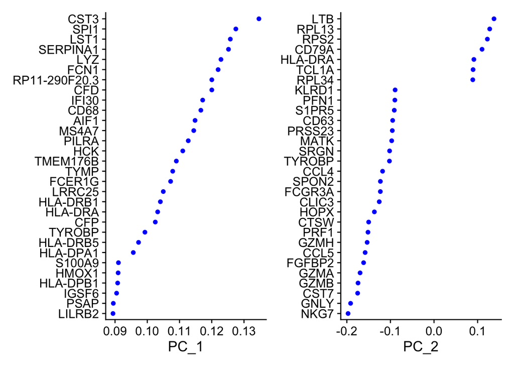

```r
VizDimLoadings(pbmc, dims = 1:2, reduction = "pca")
```

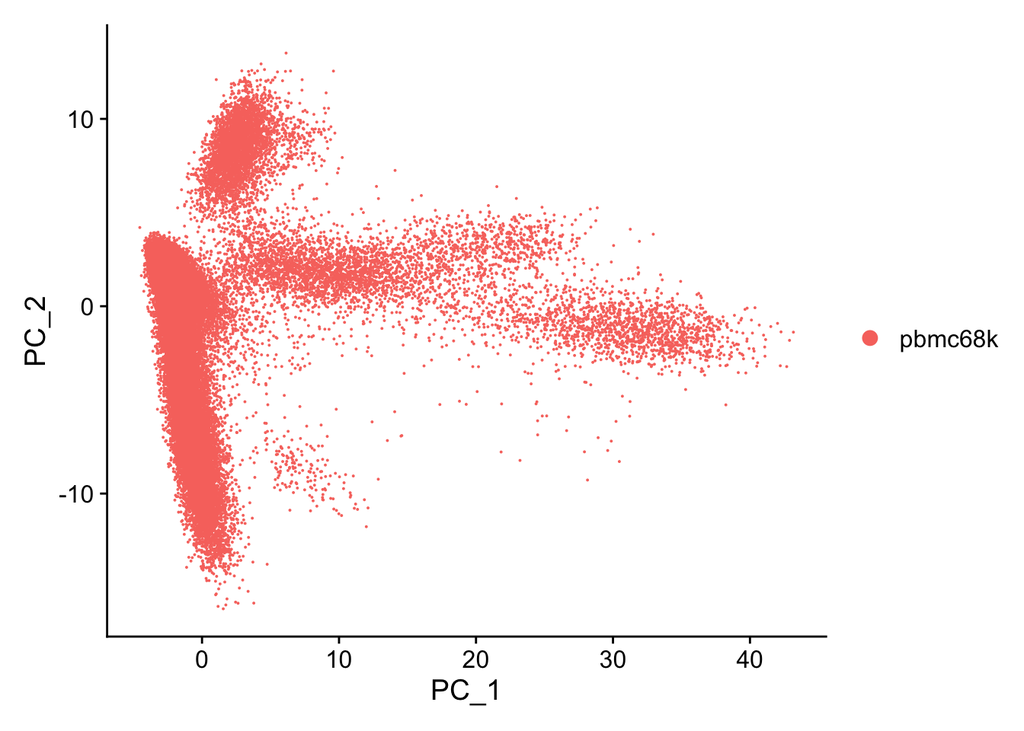

```r
DimPlot(pbmc, reduction = "pca")
```

### Determining dataset’s dimensionality

First trying with JackStraw, although it might take really long.

```r
pbmc <- JackStraw(pbmc, num.replicate = 100)
pbmc <- ScoreJackStraw(pbmc, dims = 1:20)
```

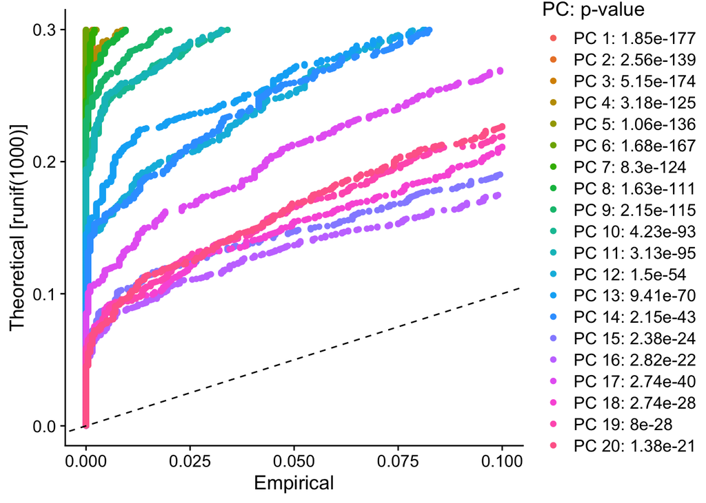

```r
JackStrawPlot(pbmc, dims = 1:20)
```

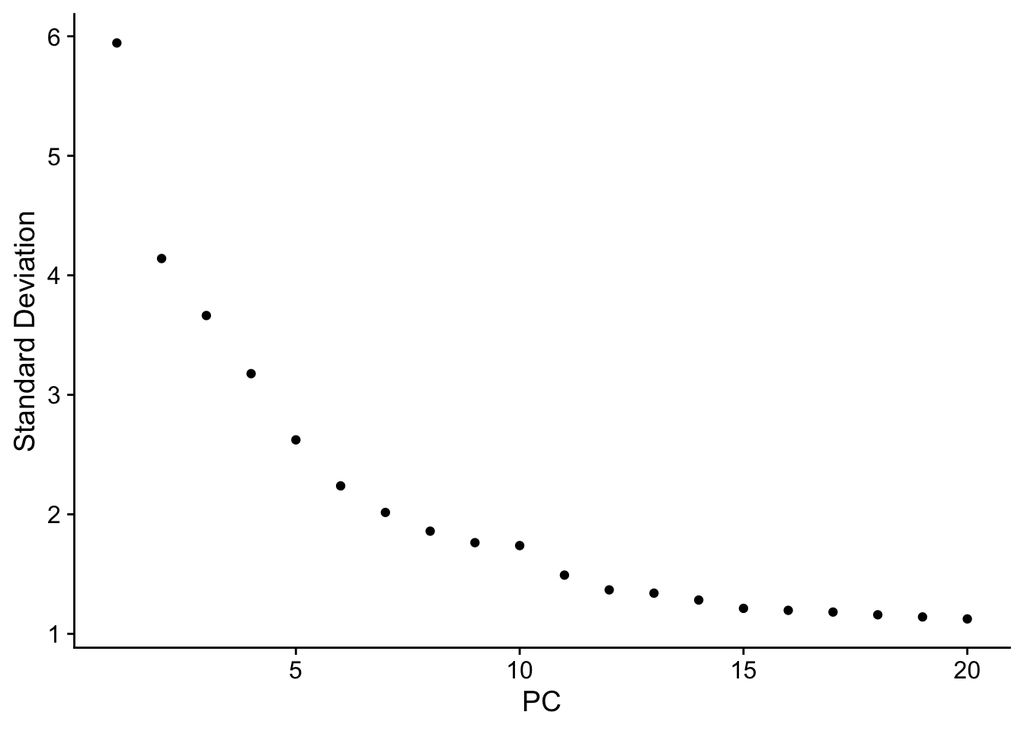

```r
ElbowPlot(pbmc)
```

```r
pbmc <- FindNeighbors(pbmc, dims = 1:15)
pbmc <- FindClusters(pbmc, resolution = 0.15)
```

```
Modularity Optimizer version 1.3.0 by Ludo Waltman and Nees Jan van Eck

Number of nodes: 68260
Number of edges: 1874630

Running Louvain algorithm...
Maximum modularity in 10 random starts: 0.9506
Number of communities: 10
Elapsed time: 22 seconds
```

### Visualizing the clustering with UMAP

t-SNE takes extremely long to compute, so sticking with UMAP (I think it’s better anyway).

```r
pbmc <- RunUMAP(pbmc, dims = 1:15)
```

```r
saveRDS(pbmc, file = "68k_pbmc.rds")
```

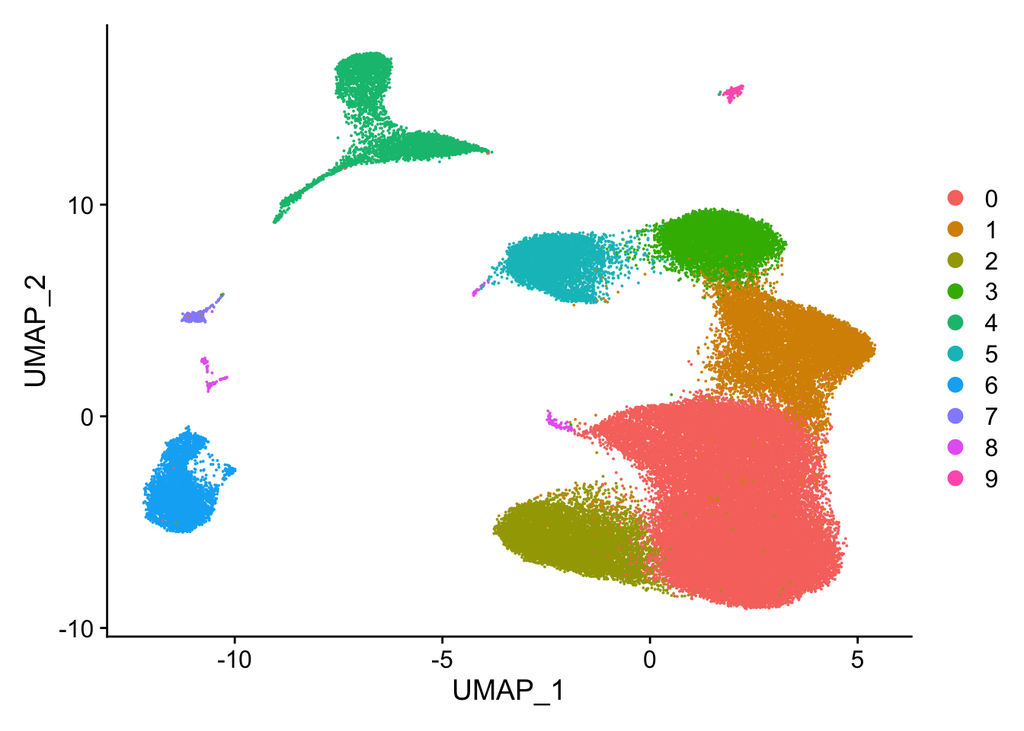

```r
DimPlot(pbmc, reduction = "umap")
```

# Homework 2

A little bit of hacking since I don’t know a better way. First I create a different Seurat object for each cluster.

```r
subclusters.objects <- list()

for (cluster.number in 0:(length(unique(pbmc[["seurat_clusters"]][[1]])) - 1)) {
  subclusters.objects[[cluster.number + 1]] <- FindSubCluster(pbmc,
                         cluster.number,
                         graph.name = "RNA_snn",
  )
}
```

```
Modularity Optimizer version 1.3.0 by Ludo Waltman and Nees Jan van Eck

Number of nodes: 30877
Number of edges: 742730

Running Louvain algorithm...
Maximum modularity in 10 random starts: 0.7754
Number of communities: 5
Elapsed time: 7 seconds
Modularity Optimizer version 1.3.0 by Ludo Waltman and Nees Jan van Eck

Number of nodes: 9827
Number of edges: 254907

Running Louvain algorithm...
Maximum modularity in 10 random starts: 0.7518
Number of communities: 6
Elapsed time: 1 seconds
Modularity Optimizer version 1.3.0 by Ludo Waltman and Nees Jan van Eck

Number of nodes: 7244
Number of edges: 185435

Running Louvain algorithm...
Maximum modularity in 10 random starts: 0.7050
Number of communities: 5
Elapsed time: 1 seconds
Modularity Optimizer version 1.3.0 by Ludo Waltman and Nees Jan van Eck

Number of nodes: 6345
Number of edges: 173007

Running Louvain algorithm...
Maximum modularity in 10 random starts: 0.6911
Number of communities: 5
Elapsed time: 1 seconds
Modularity Optimizer version 1.3.0 by Ludo Waltman and Nees Jan van Eck

Number of nodes: 4637
Number of edges: 172355
```

[output cut: 35 more lines]

```
Number of edges: 5672

Running Louvain algorithm...
Maximum modularity in 10 random starts: 0.8193
Number of communities: 4
Elapsed time: 0 seconds
Modularity Optimizer version 1.3.0 by Ludo Waltman and Nees Jan van Eck

Number of nodes: 226
Number of edges: 5203

Running Louvain algorithm...
Maximum modularity in 10 random starts: 0.7915
Number of communities: 4
Elapsed time: 0 seconds
```

```r
pbmc <- subclusters.objects[[1]]  # little hack to make sure sub.cluster field is properly intialized
```

Then I’m copying subcluster values to sub.cluster metadata in the original Seurat object.

```r
for (cluster.number in 0:(length(unique(pbmc[["seurat_clusters"]][[1]])) - 1)) {
  pbmc[["sub.cluster"]][
    pbmc[["seurat_clusters"]] == cluster.number
  ] <- subclusters.objects[[cluster.number + 1]][["sub.cluster"]][[1]][
    pbmc[["seurat_clusters"]] == cluster.number
  ]
}
```

### Visualizing subclusters in one UMAP plot.

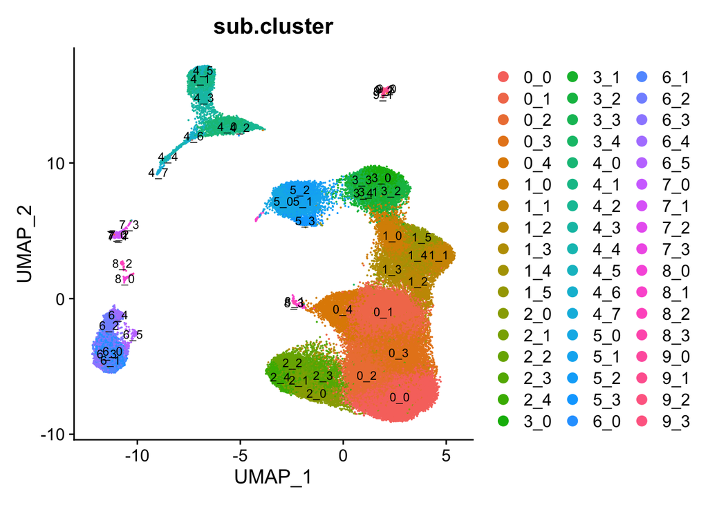

```r
DimPlot(pbmc, reduction = "umap", label = TRUE, group.by = "sub.cluster", label.size = 3)
```

```r
subsetted <- SplitObject(pbmc, split.by = "ident")
```

### Visualizing subclusters on separate plots.

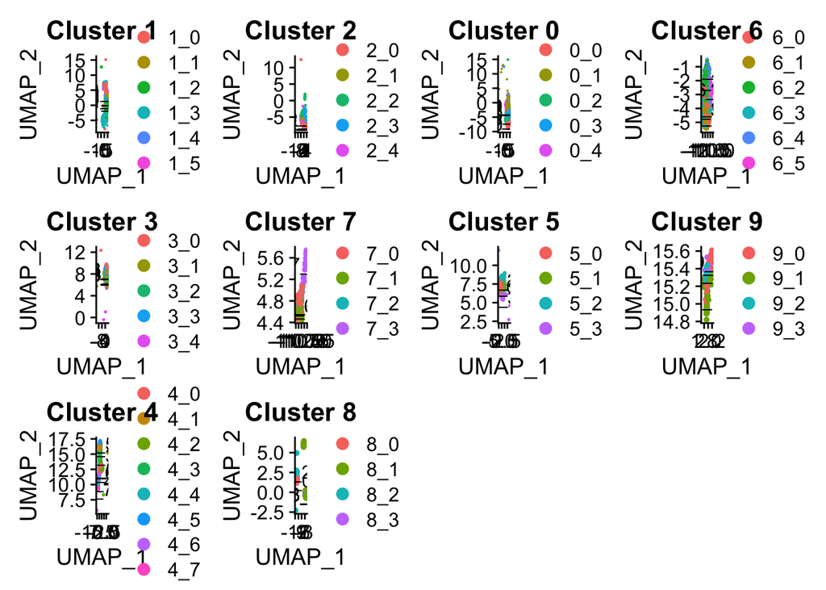

```r
first.cluster <- subsetted[[1]][["seurat_clusters"]][[1]][1]
plot <- DimPlot(
        subsetted[[1]],
        reduction = "umap",
        label = TRUE,
        group.by = "sub.cluster",
) + ggtitle(paste("Cluster", as.character(first.cluster), sep = " "))
for (i in 2:(length(unique(pbmc[["seurat_clusters"]][[1]])))) {
  cluster <- subsetted[[i]][["seurat_clusters"]][[1]][1]
  subplot <- DimPlot(
          subsetted[[i]],
          reduction = "umap",
          label = TRUE,
          group.by = "sub.cluster",
  ) + ggtitle(paste("Cluster", cluster, sep = " "))
  plot <- plot + subplot
}
plot
```